# Hyne Tumbarumba Trial: Green Board Data

### SICK camera scale factor

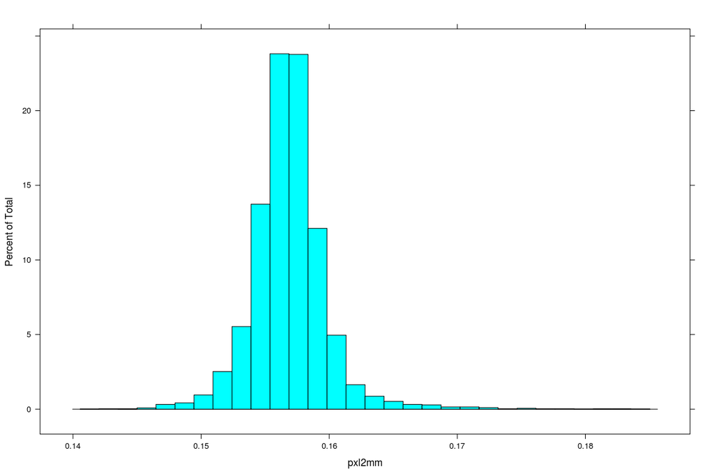

```r
histogram(~pxl2mm, nint=30, C)
```

```r
summary(C$pxl2mm)
```

```
##    Min. 1st Qu.  Median    Mean 3rd Qu.    Max.    NA's
##  0.1422  0.1553  0.1568  0.1569  0.1582  0.1834     520
```

Does SICK scale factor vary through time?

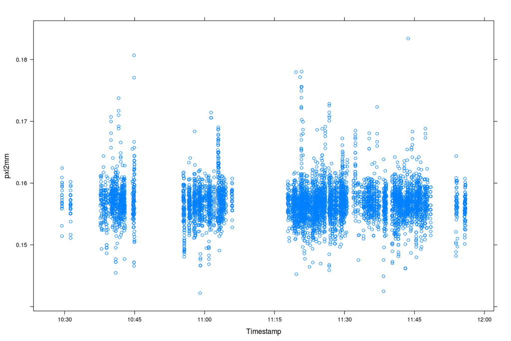

```r
ch = odbcConnect('HYNE','sa','password12')
F = sqlQuery(ch, "select b.pxl2mm, i.Timestamp from SICK_images as i left join SICK_barcodes as b on b.imageId=i.id where nboards>0")
xyplot(pxl2mm ~ Timestamp, F)
```

```r
summary(m <- cpt.mean(F$pxl2mm[is.finite(F$pxl2mm)],method='PELT'))
```

```
## Changepoint type      : Change in mean
## Method of analysis    : PELT
## Test Statistic  : Normal
## Type of penalty       : SIC with value, 8.76108
## Maximum no. of cpts   : Inf
## Changepoint Locations :
```

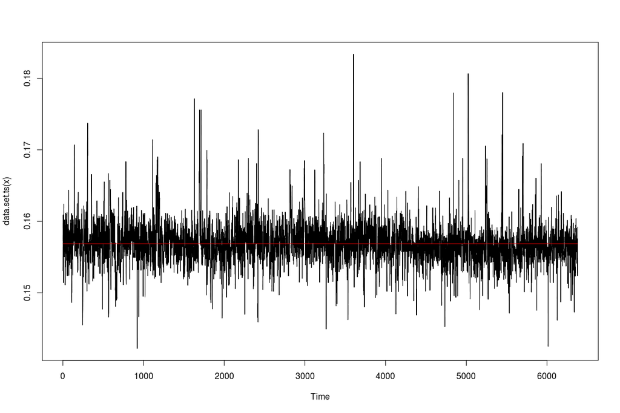

```r
plot(m) # no evidence for a shift in mean
```

Not so much.

The major outlier is image 1187, the image with two boards in one lug. The boards are from two different logs (160, 153) consequently the relative positions are meaningless.

The next worst is 1626. Based on two barcodes. Manual calcs agree, as do calcs based on individual barcodes.

Board orientation w.r.t log csys. Ideally 4 peaks separated by 90 deg. Expect the cant direction (two of the peaks separated by 180 deg) to be more popular.

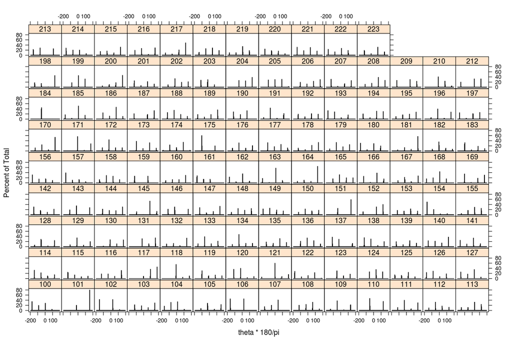

```r
histogram(~theta*180/pi | as.factor(SWILogNumber), nint=100, C)
```

### Check on board position info

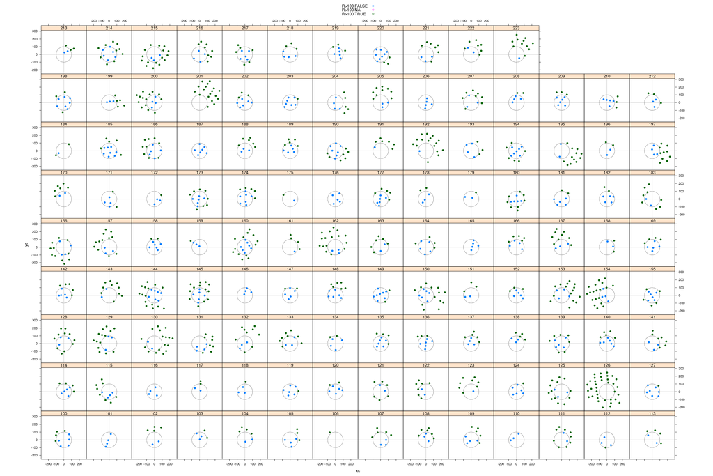

```r
circle = function(r) {
  th = seq(0,359)/2/pi
  x = r*cos(th)
  y = r*sin(th)
  return(list(x=x,y=y))
}
xyplot(yc ~ xc | as.factor(SWILogNumber), B, group=paste("R>100",(R>100)), pch=19, panel=function(x,y,...) {
  panel.abline(h=0, col="grey70")
  panel.abline(v=0, col="grey70")
  c = circle(100)
  panel.lines(c$x,c$y,lty=2,col='grey70')
  panel.xyplot(x,y,...)
}, aspect='iso', auto.key=TRUE)#, subset=SWILogNumber==154)
```

Some of the edge cases look a little dodgy, but when examined closely seem ok.

### Boards with ‘bad’ ecoustic data

Where do the boards in B.all but not in B come from?

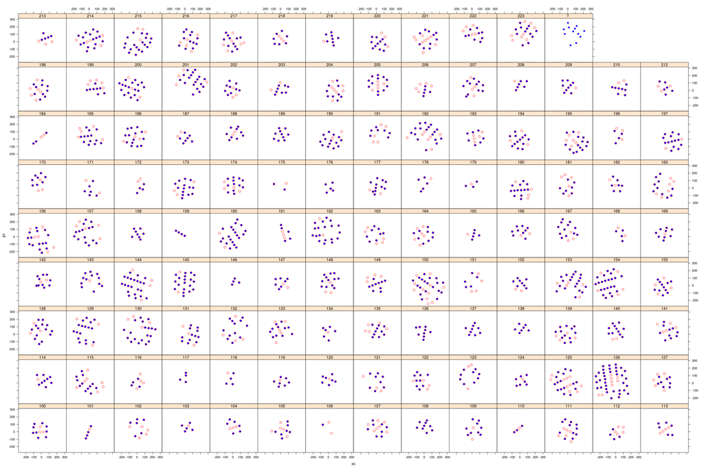

```r
xyplot(yc ~ xc | substr(SWILogNumber,1,3), B.all, col='red', cex=1.1) +
  as.layer(xyplot(yc ~ xc | SWILogNumber, B, pch=19, col='blue'))
```

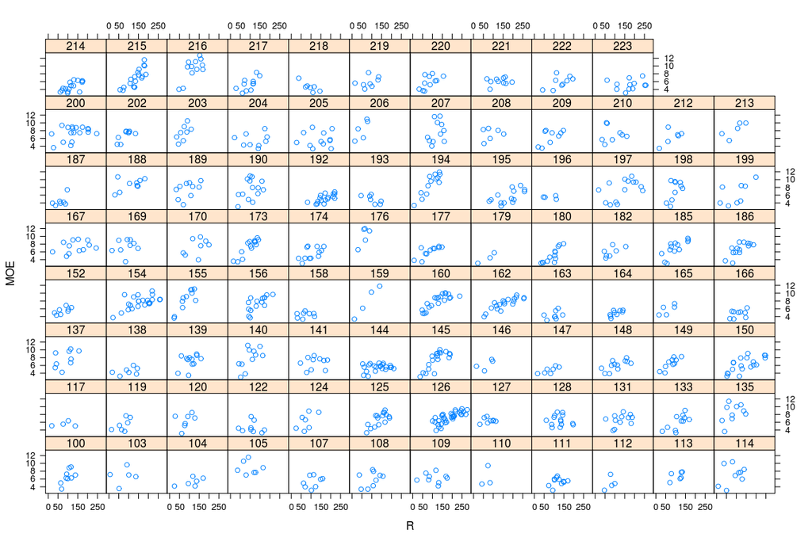

As poor a relationship as we saw in the LS15 data. Some logs have a strong pith to bark trend (e.g. 160) but others do not (e.g. 144). Possibly an accurate portrayal of change in MOE with distance from the pith, but also possibly a result of LE position poorly representing whole board position relative to the pith. Might also be influenced by green-ness (will check again when we have dry MoE).

DONE: classify boards as side/cant. see `incant.py`

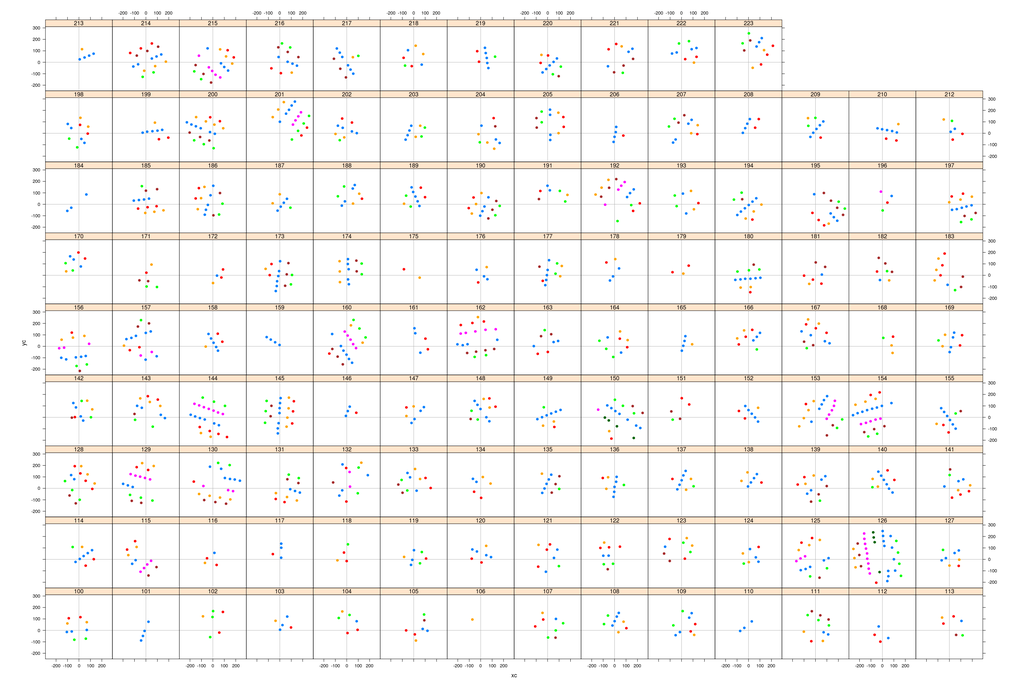

```r
xyplot(yc ~ xc | as.factor(SWILogNumber), B, group=parent, pch=19, panel=function(x,y,...) {
  panel.abline(h=0, col="grey70")
  panel.abline(v=0, col="grey70")
  #panel.abline(c(0,tan(cantAngle_rad)))
  panel.xyplot(x,y,...)
}, aspect='iso')
```

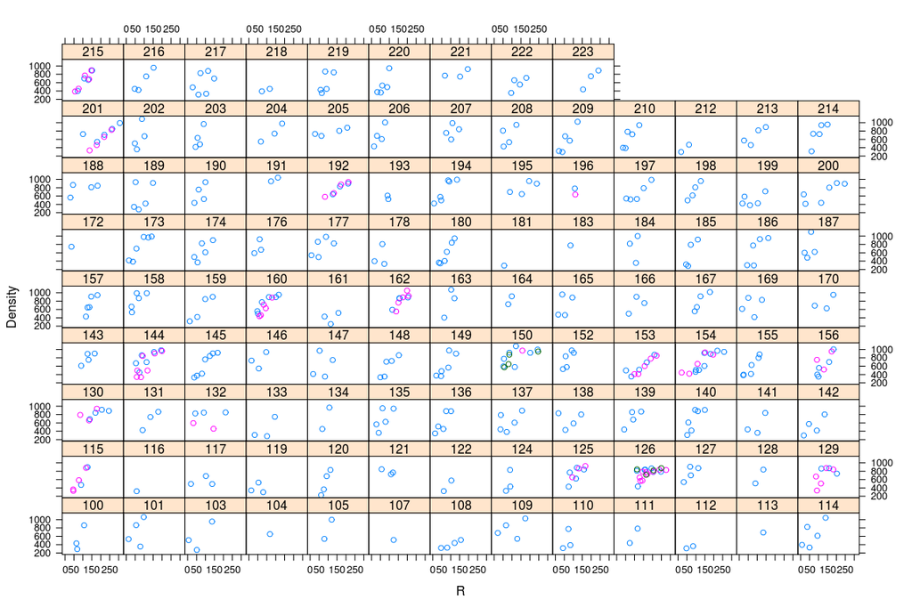

```r
xyplot(Density ~ R | as.factor(SWILogNumber), group=parent, B, type="p", subset=parent%in%c('cant1','cant2','cant3'))
```

Green density patterns look reasonable.

Plot the radial variation of MOE for just the cant boards (colour indicates cant ‘strip’):

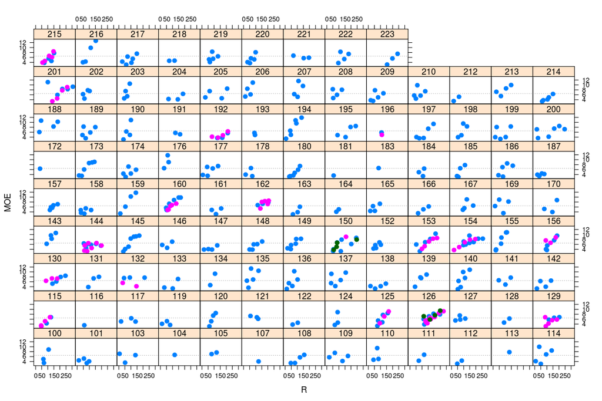

```r
xyplot(MOE ~ R | as.factor(SWILogNumber), group=parent, B, type="p",
       subset=parent%in%c('cant1','cant2','cant3'), pch=19, cex=1.,
       panel=function(...){
         panel.abline(h=6.5, col='grey70', lty=3)
         panel.xyplot(...)
       })
```

If the ecoustic green density data is unreliable, perhaps better to look at radial variation in green SWV than MOE?

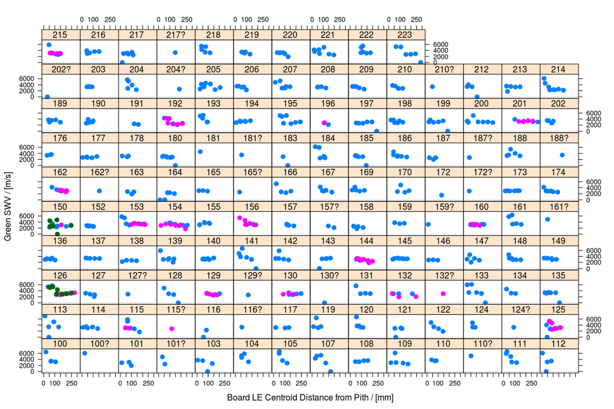

```r
xyplot(swv ~ R | as.factor(SWILogNumber), group=parent, B.all, type="p",
       subset=parent%in%c('cant1','cant2','cant3'), pch=19, cex=1.,
       panel=function(...){
         panel.abline(h=6.5, col='grey70', lty=3)
         panel.xyplot(...)
       }, ylab="Green SWV / [m/s]", xlab="Board LE Centroid Distance from Pith / [mm]")
```

As in the total ecoustic SWV data above, numerous very (impossibly?) high SWV values, typically near the pith.

Otherwise, radial MOE variation driven by radial green density variation rather than SWV (maybe?).

Where are the low MOE boards? Remember that MOE=6.5 is a default value.

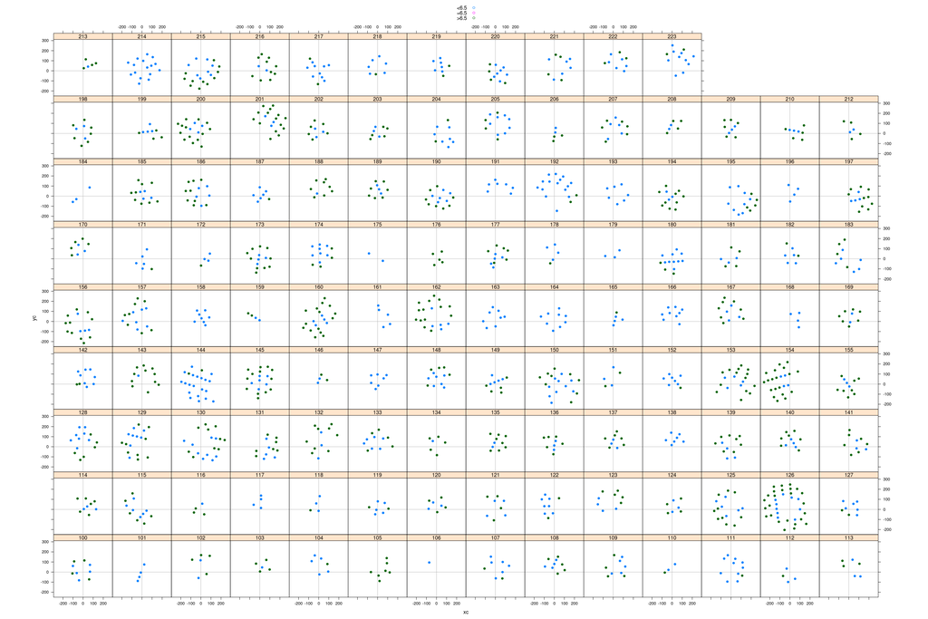

```r
B$board.class = "<6.5"
B$board.class[B$MOE==6.5] = "=6.5"
B$board.class[B$MOE>6.5] = ">6.5"
B$board.class = factor(B$board.class, levels=c('<6.5','=6.5','>6.5'), ordered=TRUE)
xyplot(yc ~ xc | as.factor(SWILogNumber), B, group=board.class, pch=19, panel=function(x,y,...) {
  panel.abline(h=0, col="grey70")
  panel.abline(v=0, col="grey70")
  #panel.abline(c(0,tan(cantAngle_rad)))
  panel.xyplot(x,y,...)
}, aspect='iso', auto.key=TRUE)
```

Hardly follows the “low MOE boards near the pith, high in the outerwood” paradigm. While some do look like that (e.g. 103, 145, 216), others run completely counter (e.g. 192, 214). Perhaps a consequence of using green swv to predict MOE?

DONE: side board c.f. cant MOE distributions. how many side boards have MOE<6.50?

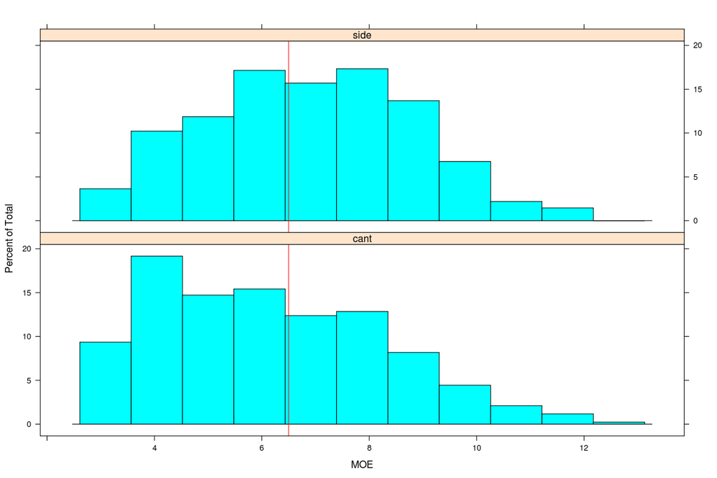

```r
histogram(~MOE | substr(parent,1,4), B, layout=c(1,2,1), subset=MOE>0&!(B$SWILogNumber%in%marco.drop), panel = function(...) {
  panel.histogram(...)
  panel.abline(v=6.5, col="red")
})
```

```r
table(paste("MOE>6.5=",B$MOE>6.5),substr(B$parent,1,4))/nrow(B)
```

```
##
##                       cant      side
##   MOE>6.5= FALSE 0.2125436 0.2146341
##   MOE>6.5= TRUE  0.1463415 0.2759582
```

```r
table(paste("MOE>6.5=",B.all$MOE>6.5),substr(B.all$parent,1,4))/nrow(B.all)
```

```
##
##                         cant        side
##   MOE>6.5= FALSE 0.200102093 0.219499745
##   MOE>6.5= NA    0.001531394 0.049515059
##   MOE>6.5= TRUE  0.139867279 0.218989280
```

### Improve grade by boxing out pith

In a mill without a cant data, what can be done to improve grade recovery?

DONE: plot probability of getting boards with stiffness<6.5GPa for different cant resawings

Plot the probability a cant board has an MOE of less than 6.5 GPa based on distance from the pith:

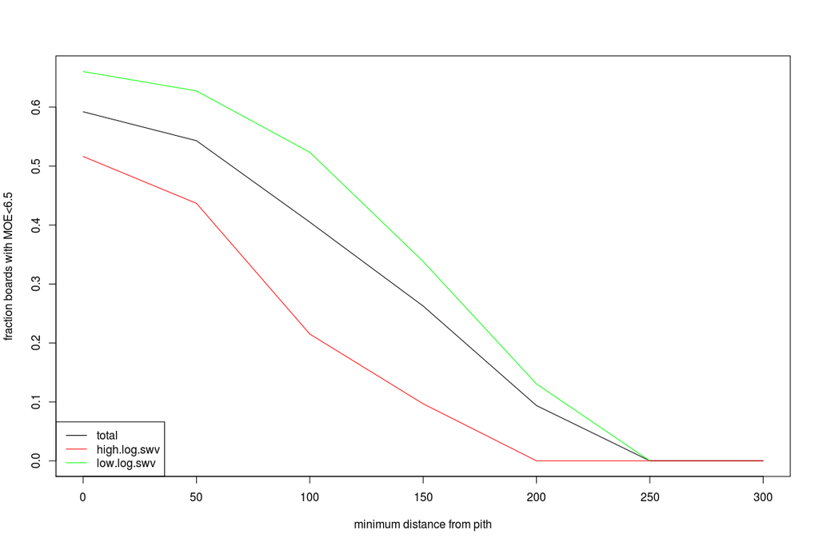

```r
C = B[substr(B$parent,1,4)=='cant',]
C = merge(C,L[,c('SWILogNumber','log.swv')],by='SWILogNumber')
C$log.class = 'low.log.swv'
C$log.class[C$log.swv>3306] = 'high.log.swv'
rs = seq(0,300,by=50)
P = data.frame()
for (i in 1:length(rs)) {
  P[i,'total'] = sum(C$MOE[C$R>=rs[i]]<6.5)/sum(C$R>=rs[i])
  for (c in unique(C$log.class)) {
    P[i,c] = sum(C$MOE[C$R>=rs[i] & C$log.class==c]<6.5)/sum(C$R>=rs[i] & C$log.class==c)
    }
}
par(mfcol=c(1,1))
matplot(rs,as.matrix(P),type="l",xlab="minimum distance from pith",ylab="fraction boards with MOE<6.5",col=c('black','red','green'),lty=1)
legend('bottomleft',names(P),lty=1,col=c('black','red','green'))
```

TODO: redraw this plot using distance from the cant outer edges instead of from the pith.

### Cant SWV

DONE: Cant SWV from cant boards

DONE: Cant SWV vs log SWV

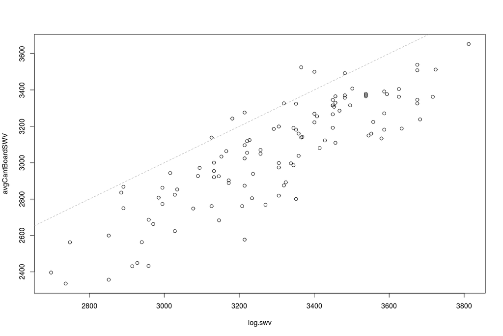

```r
par(mfcol=c(1,1))
plot(avgCantBoardSWV ~ log.swv, L)
abline(c(0,1), col='grey70', lty=2)
```

```r
summary(m <- lm(avgCantBoardSWV ~ log.swv, L)) # r^2=0.7
```

```
##
## Call:
## lm(formula = avgCantBoardSWV ~ log.swv, data = L)
##
## Residuals:
##     Min      1Q  Median      3Q     Max
## -399.93 -105.75   30.33  101.78  392.93
##
## Coefficients:
##               Estimate Std. Error t value Pr(>|t|)
## (Intercept) -325.88347  193.57395  -1.684   0.0951 .
## log.swv        1.02751    0.05858  17.540   <2e-16 ***
## ---
## Signif. codes:  0 '***' 0.001 '**' 0.01 '*' 0.05 '.' 0.1 ' ' 1
##
## Residual standard error: 151.2 on 110 degrees of freedom
##   (11 observations deleted due to missingness)
## Multiple R-squared:  0.7366, Adjusted R-squared:  0.7342
## F-statistic: 307.7 on 1 and 110 DF,  p-value: < 2.2e-16
```

Relationship between log SWV and average cant board SWV is slightly poorer (r^2=0.7) than same for average swv of all boards (r^2=0.8). Probably due to influence of side boards.

### What size are the boards?

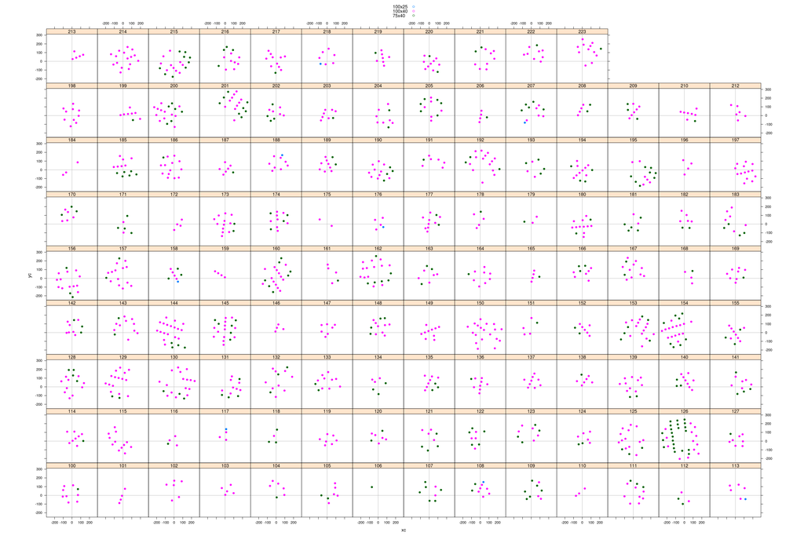

```r
B$w = '75'
B$w[B$Width>88] = '100'
B$t = '25'
B$t[B$Thickness>32] = '40'
B$board.size = paste(B$w,B$t,sep='x')
xyplot(yc ~ xc | as.factor(SWILogNumber), B, group=board.size, pch=19, panel=function(x,y,...) {
  panel.abline(h=0, col="grey70")
  panel.abline(v=0, col="grey70")
  #panel.abline(c(0,tan(cantAngle_rad)))
  panel.xyplot(x,y,...)
}, aspect='iso', auto.key=TRUE)
```

Ahh bugger. The cant from log 126 was sawn to 75x40 rather than 100x40. Must’ve been a 225mm cant?

# Recommendations

To make merge different board data streams easier:

- include lug id explicitly (is this even possible? if so, who needs to action?)
- leave tipples running and pass byproduct boards back through (though without trimming labelled end) or disable the byproduct option in the optimiser (so PLC knows about all boards)

Assigning log numbers to boards with lost/unreadable labels would be much easier if

- either the chain were flushed between logs
- or logs were trimmed, as squarely as possible, to random but distinctly different lengths (this still dosn’t help with short, waney outer boards though)

If the green and dry board data is to be merged, then to avoid extra effort need to make sure that as many barcodes as possible are read from each dry board SICK image.